# Pesticide contamination in honey from organically managed colonies in the continental USA is comparable to certified organic imports

Data and analysis

Benedict X. DeMoras[^1]

Angélica B. Sanchez[^2]

Emily O’Neil[^3]

Robyn M. Underwood[^4]

Margarita M. López-Uribe[^5]

Scott McArt[^6]

```r
library(tidyverse)      # Easier data manipulation
library(readxl)         # Import Excel files directly
library(sf)             # Spatial data
library(crawlUtils)     # Provides function to expand st_bbox limits
library(basemaps)       # Downloads base map for ggplot
library(ggspatial)      # Provides legend scale and north for map
library(ggrepel)        # Adds geom_text_repel function
library(khroma)         # Colors for heatmap
library(patchwork)      # Arrange ggplots in grids
library(ggedit)         # Ability to remove a geom for vis. abstract
library(gt)             # GTables
library(glmmTMB)        # GLMMs
library(performance)    # check_overdispersion
library(emmeans)        # Pairwise tests
library(indicspecies)   # Indicator Species Analysis
library(vegan)          # For ordinations
library(ggordiplots)    # For generating ordination plot hulls
library(colorspace)     # darken() color function
# devtools::install_github("pmartinezarbizu/pairwiseAdonis/pairwiseAdonis")
library(pairwiseAdonis) # Pairwise PERMANOVA
library(units)          # Support units in R vectors, for set_units()
library(CropScapeR)     # Retrieve CDL Data
library(MuMIn)          # AICC comparison
library(ggeffects)      # glmm predictions

source("functions/std_error.R") # Standard error calc
```

Analysis, results and figures are organized according to where they appear in the manuscript.

## 2. Methods

### Importing and cleaning data

First, we import some basic metadata on the honey samples, pesticides, USDA organic tolerances, and experimental colonies.

```r
# Import metadata
meta.Honey <- read_csv(
  "data/metadata/honey-meta.csv",
  na = "na",
  col_types = "fffff",
  col_select = -Store
)
meta.Cmpds <- read_csv(
  "data/metadata/pesticide-info-OREI.csv",
  col_types = "fffcc"
)
meta.Tols <- read_csv(
  "data/metadata/pesticide-tolerances.csv",
  col_types = "fdf"
)
meta.Cols <- read_csv(
  "data/metadata/colonies-OREI.csv",
  col_types = "ffff"
)
```

We also follow guidelines in [USDA Publication 2613: Responding to Results from Pesticide Residue Testing](https://www.ams.usda.gov/sites/default/files/media/2613.pdf) to determine whether residue levels in each sample exceed organic tolerances. Basically, there are established limits for Amitraz and Coumaphos in honey and wax. Residue limits for every other compound are set at 10 ppb.

```r
source("functions/read_pesticides.R")
# fmt: skip
data.H1.raw <- read_pesticides(
  frp_ss       = "data/pesticides/2025-04-09_BDM_Results_Project79.xlsx",
  frp_tab      = "Honey",
  frp_data     = "B4:CW77",
  frp_lims     = "E78:CW80",
  frp_pestName = "E4:CW4",
  frp_limUnits = "ng")
# fmt: skip
data.H2.raw <- read_pesticides(
  frp_ss       = "data/pesticides/2025-04-09_BDM_Results_Project79.xlsx",
  frp_tab      = "Honey",
  frp_data     = "B83:CW156",
  frp_lims     = "E157:CW159",
  frp_pestName = "E83:CW83",
  frp_limUnits = "ng")

# Store both honey dataframes in a list
list.H <- list(
  H1 = data.H1.raw,
  H2 = data.H2.raw
)
rm(data.H1.raw, data.H2.raw)

# We create a function that cleans up the pesticide data.
# This allows us to use the function on both batches of honey data at once
clean_pesticide_data <- function(x) {
  if (!any(grepl("ULOQ", names(x)))) {
    # If dataset reports ULOL vs ULOQ.
    # Mutate() functions below won't work unless we have an ULOQ value.
    # So we set this to NA just in case it's different from ULOQ
    ULOQ.col <- "ULOQ.ppb"
    x[[ULOQ.col]] <- NA
  }

  # <LOQs or >ULOQs get replaced with LOQ or ULOQ value, respectively
  x <- x %>%
    mutate(
      ppb = case_match(
        ppb,
        "<LOQ" ~ as.character(LOD.ppb),
        ">ULOQ" ~ as.character(ULOQ.ppb),
        .default = as.character(ppb)
      ),
      ppb = as.numeric(ppb),
      Cmpd = as.factor(Cmpd)
    )

  # Now we can drop the placeholder ULOQ column
  if (exists("ULOQ.col")) {
    x <- x %>% select(-starts_with("ULOQ"))
  }
  return(x)
}

# Clean up both batches of the honey dataset at once
list.H.clean <- map(list.H, ~ clean_pesticide_data(.x))

# Combine both files
data.H.Long <- bind_rows(list.H.clean[["H1"]], list.H.clean[["H2"]]) %>%
  separate_wider_delim(
    Sample.ID,
    delim = " ",
    names = c("Sample.Type", "Sample.ID")
  ) %>%
  mutate(
    Sample.ID = as.factor(as.integer(Sample.ID)),
    Cmpd = as.factor(Cmpd),
    ppb = as.numeric(ppb)
  ) %>%
  left_join(meta.Cmpds %>% select(Cmpd, Class.Pest), by = join_by(Cmpd)) %>%
  left_join(meta.Honey, by = join_by(Sample.ID)) %>%
  left_join(meta.Cols, by = join_by(Colony.ID)) %>%
  # fmt: skip
  select(Sample.ID, Colony.ID, Group, Brand, Apiary, Trt, Cmpd, Class.Pest, ppb,
    ends_with(".ppb")
  )

data.H.Wide <- data.H.Long %>%
  select(-Class.Pest, -ends_with(".ppb")) %>%
  pivot_wider(names_from = Cmpd, values_from = ppb)

# Clean up unused vars
rm(list.H, list.H.clean)

# Vectors we can use to consistently arrange the order of pesticides in
# plots and tables
styles.classLev <- c(
  "Miticide",
  "Antibiotic",
  "Synergist",
  "Insecticide",
  "Fungicide",
  "Herbicide"
)
styles.groupOrd <- c("OREI", "OG-HI", "OG-IMP", "CNV")
styles.group <- c(
  "OREI" = "Organically Managed",
  "OG-HI" = "Hawaiian Organic",
  "OG-IMP" = "Imported Organic",
  "CNV" = "Conventional"
)
```

### 2.1. Experimental apiary management

#### Figure 1. Map of the Eastern United States indicating the locations of organic apiaries in the states of New York and Pennsylvania

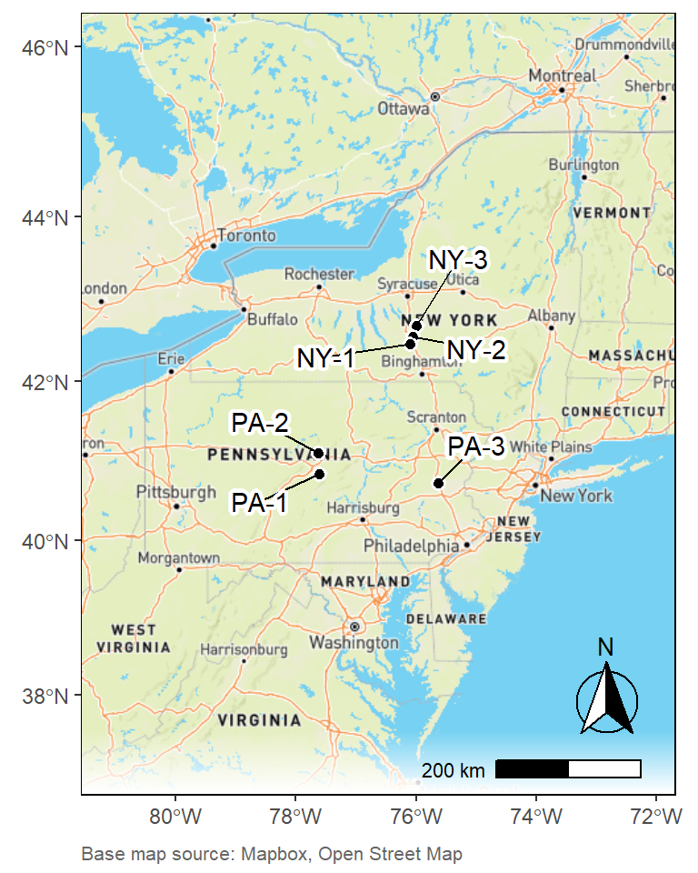

```r
# A dataframe of apiaries and GPS coordinates.
meta.farms <- read.csv("data/landscape/apiary-locations-OREI.csv")

sf.farms <- meta.farms %>%
  st_as_sf(coords = c("Lon", "Lat"), crs = 4326)

plot_map <- function(df_coords, res, expand, fPull) {
  # Convert list of apiaries into coordinates to plot
  map.coords <- df_coords %>%
    st_transform(crs = st_crs(3857)) # basemap requires EPSG 3857 web mercator

  # Get a basemap zoomed out slightly from the apiary coordinates
  # Register for an API key at https://www.thunderforest.com/ and set the credential using
  # basemaps::set_defaults()
  map.base <- basemap_gglayer(
    ext = st_expand(st_bbox(map.coords), ef = expand),
    map_service = "mapbox",
    map_type = "outdoors",
    map_res = res,
    verbose = F
  )

  # Retrieves the extents of the map we just downloaded
  map.limits <- map.base$data %>% st_as_sf(coords = c("x", "y")) %>% st_bbox()

  # Assemble the map
  map <- ggplot(data = map.coords) +
    map.base +
    scale_fill_identity() + # Plot basemap in the colors it specifies

    # Plot apiary coordinates
    geom_sf(
      aes(geometry = geometry),
      pch = 21,
      stroke = 1,
      size = 2,
      fill = "black",
      color = "white"
    ) +

    # Set limits of map to those of basemap (hide other states)
    # and remove padding between plot and axes
    scale_x_continuous(limits = map.limits[c(1, 3)], expand = c(0, 0)) +
    scale_y_continuous(limits = map.limits[c(2, 4)], expand = c(0, 0)) +

    # North arrow
    annotation_north_arrow(
      location = "br",
      pad_y = unit(0.75, "cm"),
      pad_x = unit(0.25, "cm"),
      style = north_arrow_fancy_orienteering
    ) +

    # Add a white gradient behind scale for readability.
    # See @link https://stackoverflow.com/a/72827753/5025767
    annotation_custom(
      grob = grid::rasterGrob(
        image = colorRampPalette(c("transparent", "white"), alpha = T)(10), # Gradient
        # Anchor to bottom of plot. vjust positions bottom of rect. @ y = 0
        x = unit(0.5, "npc"),
        y = unit(0, "npc"),
        vjust = 0,
        # Gradient is 100% of plot width
        width = unit(1, "npc"),
        # Height is a multiple of the scale's Y padding
        height = 4 * unit(0.25, "cm")
      )
    ) +

    # Map scale
    annotation_scale(location = "br", pad_x = unit(0.5, "cm")) +

    labs(caption = "Base map source: Mapbox, Open Street Map") +

    # Remove axis titles and gridlines
    theme(
      axis.title = element_blank(),
      panel.grid = element_blank(),
      panel.border = element_rect(fill = NA),
      plot.caption = element_text(
        hjust = 0,
        vjust = 12,
        color = "grey40",
        size = 8
      )
    )
  # Return figure
  return(map)
}

# Create a spatial dataframe of farm locations and leader lines
# # fmt: skip
sf.labels <- data.frame(
  Apiary      = c("PA-3", "PA-2", "PA-1", "NY-3", "NY-2", "NY-1"),
  lab.lon     = c(-75,    -78.6,  -78.6,  -75.3,  -75,    -77.5),
  lab.lat     = c(41.2,   41.5,   40.5,   43.5,   42.4,   42.3)) %>%
  st_as_sf(coords = c("lab.lon", "lab.lat"), crs = 4326)

# Create lines between apiaries and labels
sf.lines <- st_sf(
  crs = st_crs(sf.labels),
  Apiary = sf.labels$Apiary,
  geometry = st_sfc(mapply(
    function(p1, p2) {
      st_cast(st_union(p1, p2), "LINESTRING")
    },
    sf.labels$geometry,
    sf.farms$geometry,
    SIMPLIFY = FALSE
  ))
)

# Plot the map
(fig.1 <- plot_map(df_coords = sf.farms, res = 0.4, expand = 2) +
  geom_sf(data = sf.lines, linewidth = 0.5) +
  geom_text_repel(
    data = sf.labels,
    aes(label = Apiary, geometry = geometry),
    stat = "sf_coordinates",
    bg.r = 0.2,
    bg.color = "white",
    force = 0
  ) +
  theme(plot.caption = element_text(vjust = 0)))
```

```r
ggsave(
  "Figure_1.tiff",
  plot = fig.1,
  path = "figures",
  dpi = 500,
  width = 4,
  height = 5
)
```

#### Differences in limits between both UHPLC-MS/MS batches

```r
difference <- function(vec) {
  diff <- max(vec) - min(vec)
  return(diff)
}

# Get just the compounds and limits
df.limits <- data.H.Long %>%
  select(Cmpd, ends_with(".ppb")) %>%
  unique()

df.limits %>%
  arrange(Cmpd) %>% # Sorts by compound. We see there's 2 limits for each compound.
  group_by(Cmpd) %>% # for each compound,
  # Compute difference between limits
  summarise(
    across(ends_with(".ppb"), list(diff = difference)),
    .groups = "drop"
  ) %>%
  # Now, for each limit, average differences across compounds and compute std. error.
  summarise(across(ends_with("_diff"), list(mean = mean, SE = std_error))) %>%
  signif(digits = 2) %>%
  # Values are easier to read if listed vertically
  transpose(keep.names = "Difference") %>%
  rename("Value (ppb)" = V1)
```

```
##           Difference Value (ppb)
## 1  LOD.ppb_diff_mean       0.071
## 2    LOD.ppb_diff_SE       0.020
## 3  LOQ.ppb_diff_mean       0.210
## 4    LOQ.ppb_diff_SE       0.060
## 5 ULOQ.ppb_diff_mean       5.600
## 6   ULOQ.ppb_diff_SE       0.000
```

```r
# Save most conservative limit (maximum) for reporting in output tables
df.limits <- df.limits %>%
  group_by(Cmpd) %>%
  summarize(across(ends_with(".ppb"), ~ max(.)))
```

#### Table S2. List of 96 pesticides screened in honey samples

```r
# Summary table by compound --------------------------------------------------------
df.cmpdSumm <- data.H.Long %>%
  group_by(Cmpd, Class.Pest) %>%
  # fmt: skip
  summarize(
      n.detect   = n_distinct(Sample.ID[ppb>0]),
      pct.detect = ifelse(n.detect > 0, n.detect / n_distinct(Sample.ID), NA),
      ppb.mean   = ifelse(n.detect > 0, mean(ppb),      NA),
      ppb.se     = ifelse(n.detect > 0, std_error(ppb), NA),
      ppb.min    = ifelse(n.detect > 0, min(ppb),       NA),
      ppb.max    = ifelse(n.detect > 0, max(ppb),       NA),
      .groups    = "drop") %>%
  arrange(desc(pct.detect)) %>%
  # Convert to factor in current order. Useful for charts using this dataframe
  mutate(
    Class.Pest = factor(Class.Pest, ordered = T, levels = styles.classLev)
  ) %>%

  # Add organic MRLS
  left_join(
    meta.Tols %>%
      select(Cmpd, MRL.H.ppm) %>%
      mutate(
        MRL.OG.ppb = MRL.H.ppm * 0.05 * 1000, # 5% of EPA, convert to ppb
        # Cmpd       = factor(Cmpd, ordered = T, levels = rev(df.cmpdSumm$Cmpd)),
        .keep = "unused"
      ),
    by = "Cmpd"
  ) %>%
  # Any compound with an undefined tolerance is set at 10ppb
  mutate(MRL.OG.ppb = ifelse(is.na(MRL.OG.ppb), 10, MRL.OG.ppb)) %>%

  # Add LOD and LOQs to summary table
  left_join(df.limits %>% select(-ULOQ.ppb), by = "Cmpd")

# Generate a nice clean table -------------------------------------------------------
df.cmpdSumm %>%
  select(-n.detect) %>%
  relocate(pct.detect, LOD.ppb, LOQ.ppb, MRL.OG.ppb, .before = ppb.mean) %>%
  # filter(ppb.mean > 0) %>%  # HIDE COMPOUNDS NOT DETECTED
  group_by(Class.Pest) %>%
  arrange(Class.Pest, desc(pct.detect)) %>%

  gt(rowname_col = "Cmpd") %>%
  tab_stubhead("Compound") %>%

  # Replace NAs with Not Detected
  sub_missing(missing_text = "ND") %>%

  fmt_number(columns = c(starts_with("ppb")), decimals = 3) %>%
  fmt_percent(columns = pct.detect, decimals = 1) %>%

  tab_spanner(label = "Amounts (ppb)", columns = 4:10) %>%
  # fmt: skip
  cols_label(
      ppb.mean   = "Mean",      ppb.se     = "SE",
      ppb.min    = "Min",       ppb.max    = "Max",
      pct.detect = "% Samples", MRL.OG.ppb = "Organic MRL",
      LOD.ppb    = "LOD",       LOQ.ppb    = "LOQ") %>%
  tab_options(table.align = "left")
```

| Compound | % Samples | Amounts (ppb) LOD | Amounts (ppb) LOQ | Amounts (ppb) Organic MRL | Amounts (ppb) Mean | Amounts (ppb) SE | Amounts (ppb) Min | Amounts (ppb) Max |
| --- | --- | --- | --- | --- | --- | --- | --- | --- |
| Miticide |  |  |  |  |  |  |  |  |
| 2,4-DMPF | 19.2% | 1.42 | 4.26 | 10.0 | 1.805 | 0.399 | 0.000 | 32.970 |
| 2,4-DMA | 7.5% | 2.95 | 8.88 | 10.0 | 0.999 | 0.303 | 0.000 | 16.671 |
| Coumaphos oxon | 6.8% | 0.28 | 0.85 | 7.5 | 0.032 | 0.013 | 0.000 | 1.318 |
| Coumaphos | 0.7% | 4.73 | 14.20 | 7.5 | 0.032 | 0.032 | 0.000 | 4.710 |
| Antibiotic |  |  |  |  |  |  |  |  |
| Avermectin B1a | ND | 2.84 | 8.52 | 10.0 | ND | ND | ND | ND |
| Synergist |  |  |  |  |  |  |  |  |
| Piperonyl butoxide | 41.1% | 0.05 | 0.14 | 10.0 | 0.495 | 0.114 | 0.000 | 10.688 |
| Insecticide |  |  |  |  |  |  |  |  |
| (E)-Fenpyroximate | 4.1% | 0.11 | 0.34 | 10.0 | 0.012 | 0.006 | 0.000 | 0.688 |
| Acetamiprid | 4.1% | 0.24 | 0.71 | 10.0 | 0.027 | 0.012 | 0.000 | 1.242 |
| Thiamethoxam | 2.1% | 0.95 | 2.84 | 10.0 | 0.020 | 0.011 | 0.000 | 0.950 |
| Tebufenozide | 0.7% | 0.14 | 0.42 | 10.0 | 0.003 | 0.003 | 0.000 | 0.421 |
| (S)-Indoxacarb | ND | 1.14 | 3.41 | 10.0 | ND | ND | ND | ND |
| Acephate | ND | 7.10 | 21.30 | 10.0 | ND | ND | ND | ND |
| Aldicarb | ND | 99.42 | 298.25 | 10.0 | ND | ND | ND | ND |
| Aldicarb sulfone | ND | 4.73 | 14.20 | 10.0 | ND | ND | ND | ND |
| Azinphos methyl | ND | 2.36 | 7.07 | 10.0 | ND | ND | ND | ND |
| Bendiocarb | ND | 0.31 | 0.93 | 10.0 | ND | ND | ND | ND |
| Carbaryl | ND | 0.28 | 0.85 | 10.0 | ND | ND | ND | ND |
| Carbofuran | ND | 0.07 | 0.21 | 10.0 | ND | ND | ND | ND |
| Chlorantraniliprole | ND | 0.71 | 2.13 | 10.0 | ND | ND | ND | ND |
| Chlorpyrifos | ND | 5.92 | 17.75 | 10.0 | ND | ND | ND | ND |
| Chlorpyrifos methyl | ND | 42.61 | 127.82 | 10.0 | ND | ND | ND | ND |
| Clothianidin | ND | 0.85 | 2.56 | 10.0 | ND | ND | ND | ND |
| Cyantraniliprole | ND | 1.13 | 3.40 | 10.0 | ND | ND | ND | ND |
| Diazinon | ND | 0.09 | 0.26 | 10.0 | ND | ND | ND | ND |
| Diflubenzuron | ND | 9.47 | 28.41 | 10.0 | ND | ND | ND | ND |
| Dinotefuran | ND | 3.55 | 10.65 | 10.0 | ND | ND | ND | ND |

[output cut: 72 more lines]

## 3. Results

### 3.0. Contamination summary

#### Summary table of exposure (not in text)

```r
# =(1) Prep data: we need the formatted data from figs. 2 & 3 for the following table
# ===================================================================================
df.none <- df.cmpdSumm %>% filter(n.detect == 0) %>% select(Cmpd)
df.fig2.heat <- data.H.Long %>%
  # Remove compounds w/ no detections
  anti_join(df.none, by = join_by(Cmpd)) %>%

  # Organic tolerances
  left_join(
    df.cmpdSumm %>% select(Cmpd, MRL.OG.ppb),
    by = "Cmpd"
  ) %>%

  select(
    Colony.ID,
    Sample.ID,
    Apiary,
    Trt,
    Cmpd,
    Class.Pest,
    ppb,
    MRL.OG.ppb,
    Group,
    Brand
  ) %>%

  # Threshold detections based on OG tolerances
  mutate(
    Exceed.Tol = ifelse(
      ppb == 0,
      "No Detection", # 0 ppb, cmpd not detected. Otherwise,
      ifelse(ppb > MRL.OG.ppb, "Yes", "No")
    ), # check detection against tolerance

    Exceed.Tol = factor(
      Exceed.Tol,
      ordered = T,
      levels = c("Yes", "No", "No Detection")
    ),

    # Set order of groups on plots
    Group = factor(Group, ordered = T, levels = styles.groupOrd)
  )

df.fig3.summ <- data.H.Long %>%
  group_by(across(c(-Cmpd, -ends_with(".ppb"), -Class.Pest, -ppb))) %>%
  summarize(
    # Count the number of compounds where ppb > 0
    num.Cmpd = length(ppb[ppb > 0]),
    # Simply sum the total ppb
    ppb.sum = sum(ppb),
    .groups = "drop"
  ) %>%
  mutate(
    Brand = as_factor(ifelse(
      is.na(Brand),
      as.character(Apiary),
      as.character(Brand)
    ))
  ) %>%
  select(-Apiary) %>%
  mutate(Group = factor(Group, ordered = T, levels = styles.groupOrd))

# =(2) Generate a summary table for reporting results ===============================
summTab <- function(x) {
  summarize(
    x,
    sum.mean = mean(ppb.sum),
    sum.se = std_error(ppb.sum),
    sum.min = min(ppb.sum),
    sum.max = max(ppb.sum),
    N.mean = mean(num.Cmpd),
    N.se = std_error(num.Cmpd),
    N.min = min(num.Cmpd),
    N.max = max(num.Cmpd)
  )
}

bind_rows(
  df.fig3.summ %>%
    group_by(Group) %>% # Dataframe summarizing detections by group
    summTab,

  df.fig3.summ %>%
    ungroup() %>% # Dataframe that summarizes across all data
    summTab %>%
    mutate(Group = "All")
) %>%

  left_join(
    # Number of compounds detected
    bind_rows(
      df.fig2.heat %>%
        group_by(Group) %>% # In each group
        summarize(Cmpds = n_distinct(Cmpd[ppb > 0])),

      # All groups
      data.frame(
        Group = "All",
        Cmpds = df.fig2.heat %>% pull(Cmpd) %>% unique() %>% length()
      )
    ),
    by = join_by(Group)
  ) %>%
  relocate(Cmpds, .after = Group) %>%
  mutate(
    "Type of honey" = case_match(
      Group,
      "OREI" ~ "Organically Managed",
      "OG-HI" ~ "Hawaiian Organic",
      "OG-IMP" ~ "Imported Organic",
      "CNV" ~ "Conventional",
      .default = Group
    ),
    .keep = "unused",
    .before = everything()
  ) %>%

  gt() %>%
  tab_spanner(label = "Summed amount/sample (ppb)", columns = 3:6) %>%
  tab_spanner(label = "Number of compounds/sample", columns = 7:10) %>%
  fmt_number(
    columns = starts_with("sum."),
    decimals = 2,
    drop_trailing_zeros = T
  ) %>%
  fmt_number(
    columns = starts_with("N."),
    decimals = 1,
    drop_trailing_zeros = T
  ) %>%
  cols_label(
    Cmpds ~ "Number compounds detected",
    ends_with("mean") ~ "Mean",
    ends_with("se") ~ "SE",
    ends_with("min") ~ "Min.",
    ends_with("Max") ~ "Max."
  ) %>%
  tab_options(table.align = "left")
```

| Type of honey | Number compounds detected | Summed amount/sample (ppb) Mean | Summed amount/sample (ppb) SE | Summed amount/sample (ppb) Min. | Summed amount/sample (ppb) Max. | Number of compounds/sample Mean | Number of compounds/sample SE | Number of compounds/sample Min. | Number of compounds/sample Max. |
| --- | --- | --- | --- | --- | --- | --- | --- | --- | --- |
| Organically Managed | 8 | 1.2 | 0.28 | 0 | 10.8 | 1.1 | 0.1 | 0 | 3 |
| Hawaiian Organic | 4 | 5.18 | 1.23 | 0 | 16.67 | 0.6 | 0.1 | 0 | 2 |
| Imported Organic | 4 | 2.72 | 0.35 | 0.13 | 7.42 | 1.2 | 0.1 | 1 | 2 |
| Conventional | 11 | 9.34 | 1.68 | 0 | 38.59 | 2.6 | 0.2 | 0 | 5 |
| All | 16 | 4 | 0.51 | 0 | 38.59 | 1.3 | 0.1 | 0 | 5 |

```r
rm(summTab)
```

#### Figure 2. Heatmap showing overall pesticide residue content of the sampled honeys

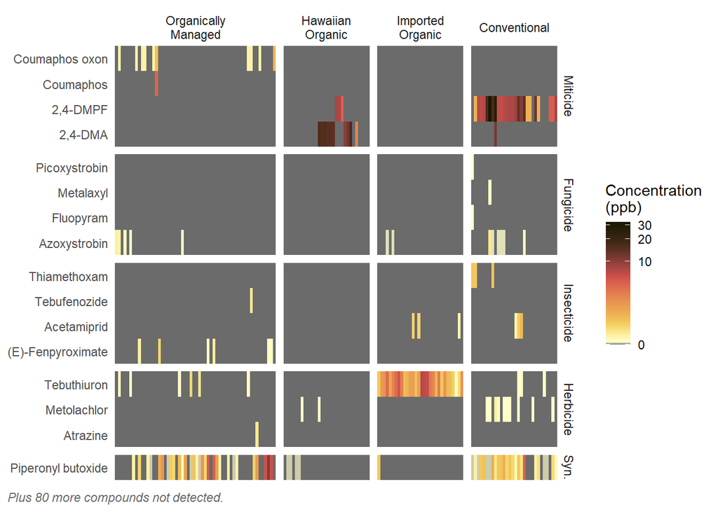

```r
# Build styles for plot -------------------------------------------------------------
colors.heat <- c("grey42", rev(color("lajolla")(49)))
colors.tols <- c(
  "Yes" = color("lajolla")(3)[2],
  "No" = "grey80",
  "No Detection" = "grey40"
)

styles.heat <- list(
  theme_classic(),

  # Remove things we don't need from theme
  # fmt: skip
  theme(
    axis.ticks            = element_blank(),
    axis.text.x           = element_blank(),
    axis.title.x          = element_blank(),
    axis.title.y          = element_blank(),
    axis.line.x           = element_blank(),
    axis.line.y           = element_blank(),
    strip.background      = element_rect(fill = NA, color = NA),
    plot.caption.position = "plot",
    plot.caption          = element_text(hjust = 0, color = "grey40",
                                         face = "italic")),

  # Remove some odd spacing between panel border and plot. See:
  # https://stackoverflow.com/a/22945857
  scale_x_discrete(expand = c(0, 0)),
  scale_y_discrete(expand = c(0, 0))
)

df.fig2.heat <- df.fig2.heat %>%
  mutate(Class.Pest = recode(Class.Pest, "Synergist" = "Syn."))

# Plot overall exposure ------------------------------------------------------------
(fig.2 <- ggplot(data = df.fig2.heat) +
  geom_tile(aes(x = Sample.ID, y = Cmpd, fill = ppb), alpha = 1) +
  facet_grid(
    Class.Pest ~ Group,
    scales = "free",
    space = "free",
    labeller = labeller(
      # Wrap the Group facet labels at 13 characters
      Group = setNames(str_wrap(styles.group, width = 13), names(styles.group))
    )
  ) +
  scale_fill_gradientn(
    name = "Concentration\n(ppb)", # Title of the scale
    colors = colors.heat, # The colors we defined earlier
    trans = "log1p"
  ) + # Log(0) is infinite, so log(ppb+1)
  labs(caption = "Plus 80 more compounds not detected.") +
  styles.heat)
```

```r
ggsave(
  "Figure_2.tiff",
  plot = fig.2,
  path = "figures",
  dpi = 500,
  width = 7,
  height = 5
)
```

### 3.1. Pesticide contamination across sampled honeys

#### Stats for figure 3: Comparing contamination across groups of honey

First, we use the number of compounds per sample as the response variable.

```r
# Number of residues vs. Group -----------------------------------------------------
m.fig3A <- glmmTMB(
  num.Cmpd ~ Group + (1 | Brand),
  data = df.fig3.summ,
  family = "poisson"
)

# summary(m.fig3A)
# check_overdispersion(m.fig3A)

m.fig3ANULL <- glmmTMB(
  num.Cmpd ~ (1 | Brand),
  data = df.fig3.summ,
  family = "poisson"
)

anova(m.fig3A, m.fig3ANULL)
```

```
## Data: df.fig3.summ
## Models:
## m.fig3ANULL: num.Cmpd ~ (1 | Brand), zi=~0, disp=~1
## m.fig3A: num.Cmpd ~ Group + (1 | Brand), zi=~0, disp=~1
##             Df    AIC    BIC  logLik deviance  Chisq Chi Df Pr(>Chisq)
## m.fig3ANULL  2 401.77 407.73 -198.88   397.77
## m.fig3A      5 372.09 387.01 -181.05   362.09 35.671      3  8.787e-08 ***
## ---
## Signif. codes:  0 '***' 0.001 '**' 0.01 '*' 0.05 '.' 0.1 ' ' 1
```

```r
(stat.emm.f3A <- summary(emmeans(m.fig3A, pairwise ~ Group, type = "response")))
```

```
## $emmeans
##  Group   rate    SE  df asymp.LCL asymp.UCL
##  OREI   1.071 0.138 Inf     0.832     1.380
##  OG-HI  0.633 0.145 Inf     0.404     0.993
##  OG-IMP 1.200 0.200 Inf     0.866     1.664
##  CNV    2.633 0.296 Inf     2.112     3.283
##
## Confidence level used: 0.95
## Intervals are back-transformed from the log scale
##
## $contrasts
##  contrast           ratio     SE  df null z.ratio p.value
##  OREI / (OG-HI)     1.692 0.4450 Inf    1   1.997  0.1890
##  OREI / (OG-IMP)    0.893 0.1880 Inf    1  -0.538  0.9499
##  OREI / CNV         0.407 0.0697 Inf    1  -5.251 <0.0001
##  (OG-HI) / (OG-IMP) 0.528 0.1500 Inf    1  -2.254  0.1091
##  (OG-HI) / CNV      0.241 0.0615 Inf    1  -5.577 <0.0001
##  (OG-IMP) / CNV     0.456 0.0916 Inf    1  -3.908  0.0005
##
## P value adjustment: tukey method for comparing a family of 4 estimates
## Tests are performed on the log scale
```

Then we look at the total amount of residues in each sample as the response variable.

```r
# Amount of residues vs. group ------------------------------------------------------
m.fig3B <- glmmTMB(
  ppb.sum ~ Group + (1 | Brand),
  data = df.fig3.summ,
  family = "tweedie"
)

m.fig3BNULL <- glmmTMB(
  ppb.sum ~ (1 | Brand),
  data = df.fig3.summ,
  family = "tweedie"
)

anova(m.fig3B, m.fig3BNULL)
```

```
## Data: df.fig3.summ
## Models:
## m.fig3BNULL: ppb.sum ~ (1 | Brand), zi=~0, disp=~1
## m.fig3B: ppb.sum ~ Group + (1 | Brand), zi=~0, disp=~1
##             Df    AIC    BIC  logLik deviance  Chisq Chi Df Pr(>Chisq)
## m.fig3BNULL  4 636.42 648.35 -314.21   628.42
## m.fig3B      7 620.92 641.81 -303.46   606.92 21.494      3  8.311e-05 ***
## ---
## Signif. codes:  0 '***' 0.001 '**' 0.01 '*' 0.05 '.' 0.1 ' ' 1
```

```r
(stat.emm.f3b <- summary(emmeans(m.fig3B, pairwise ~ Group, type = "response")))
```

```
## $emmeans
##  Group  response    SE  df asymp.LCL asymp.UCL
##  OREI      0.761 0.439 Inf     0.245      2.36
##  OG-HI     0.885 0.602 Inf     0.233      3.36
##  OG-IMP    2.185 0.858 Inf     1.011      4.72
##  CNV       5.948 2.300 Inf     2.792     12.67
##
## Confidence level used: 0.95
## Intervals are back-transformed from the log scale
##
## $contrasts
##  contrast           ratio     SE  df null z.ratio p.value
##  OREI / (OG-HI)     0.860 0.7650 Inf    1  -0.170  0.9983
##  OREI / (OG-IMP)    0.348 0.2430 Inf    1  -1.512  0.4303
##  OREI / CNV         0.128 0.0887 Inf    1  -2.964  0.0160
##  (OG-HI) / (OG-IMP) 0.405 0.3170 Inf    1  -1.156  0.6546
##  (OG-HI) / CNV      0.149 0.1160 Inf    1  -2.451  0.0679
##  (OG-IMP) / CNV     0.367 0.0908 Inf    1  -4.052  0.0003
##
## P value adjustment: tukey method for comparing a family of 4 estimates
## Tests are performed on the log scale
```

#### Figure 3. Comparison of the number of pesticide residues in sampled honey and the summed amount of residues per sample

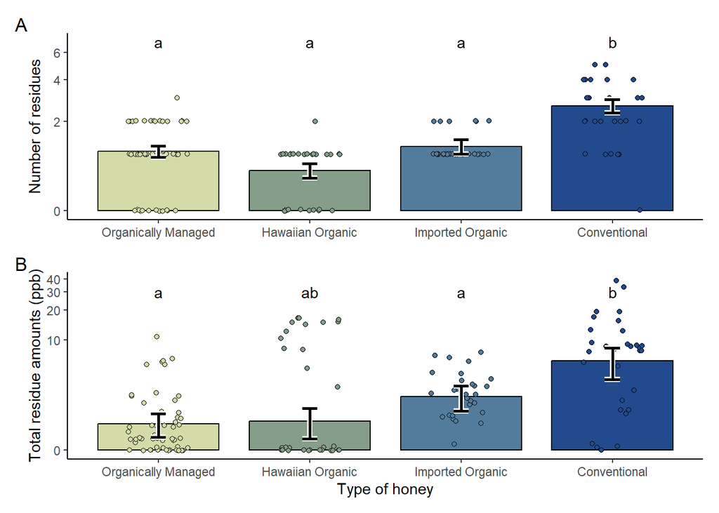

```r
# Define plot styles
styles.colors <- color("davos", reverse = T)(6)[2:5]

# Significance labels
# fmt: skip
df.fig3.signif <- tibble(
  Sample.Type  = rep("Honey", 4),
  Group        = c("OG-HI", "OG-IMP", "CNV", "OREI"),
  Contrast.Nr  = c("a", "a", "b", "a"),
  y.Nr         = rep(7, 4),
  Contrast.Amt = c("ab", "a", "b", "a"),
  y.Amt        = rep(30, 4)
)

# Build plots -------------------------------------------------------------------
fig.3a <- ggplot(
  data = stat.emm.f3A$emmeans,
  aes(x = Group, y = rate, fill = Group)
) +
  geom_col(
    position = position_dodge(0.9),
    width = 0.8,
    color = "black",
    alpha = 1
  ) +
  geom_jitter(
    data = df.fig3.summ,
    aes(y = num.Cmpd),
    position = position_jitter(height = 0.01, width = 0.2),
    alpha = 1,
    shape = 21,
    color = "black"
  ) +
  geom_errorbar(
    aes(ymin = rate - SE, ymax = rate + SE),
    width = 0.1,
    linewidth = 1.8,
    color = "white"
  ) +
  geom_errorbar(
    aes(ymin = rate - SE, ymax = rate + SE),
    width = 0.1,
    linewidth = 1
  ) +
  geom_text(
    data = df.fig3.signif,
    aes(x = Group, y = y.Nr, label = Contrast.Nr)
  ) +
  ylab("Number of residues")

fig.3b <- ggplot(
  data = stat.emm.f3b$emmeans,
  aes(x = Group, y = response, fill = Group)
) +
  geom_col(
    position = position_dodge(0.9),
    width = 0.8,
    color = "black",
    alpha = 1
  ) +
  geom_jitter(
    data = df.fig3.summ,
    aes(y = ppb.sum),
    position = position_jitter(height = 0.01, width = 0.2),
    alpha = 1,
    shape = 21,
    color = "black"
  ) +
  geom_errorbar(
    aes(ymin = response - SE, ymax = response + SE),
    width = 0.1,
    linewidth = 1.8,
    color = "white"
  ) +
  geom_errorbar(
    aes(ymin = response - SE, ymax = response + SE),
    width = 0.1,
    linewidth = 1
  ) +
  geom_text(
    data = df.fig3.signif,
    aes(x = Group, y = y.Amt, label = Contrast.Amt)
  ) +
  ylab("Total residue amounts (ppb)")

(fig.3a /
  fig.3b +
  plot_layout(axis_titles = "collect_x") &
  coord_trans(y = "log1p") &
  scale_x_discrete(labels = styles.group) &
  scale_fill_manual(values = styles.colors) &
  xlab("Type of honey") &
  theme_classic() &
  theme(legend.position = "none")) +
  plot_annotation(tag_levels = 'A')
```

```r
ggsave(
  "Figure_3.tiff",
  plot = last_plot(),
  path = "figures",
  dpi = 500,
  width = 7,
  height = 5
)
```

#### Table S3. Positive compound detections within each group of sampled honey

```r
df.fig2.heat %>%
  group_by(Cmpd, Class.Pest, Group) %>%
  # fmt: skip
  summarize(
    n.detects   = length(Cmpd[ppb > 0]),
    pct.detect  = n.detects / n_distinct(Sample.ID),
    mean        = mean(ppb),
    se          = std_error(ppb),
    max         = max(ppb),
    MRL.OG.ppb  = first(MRL.OG.ppb),
    n.exceedTol = length(Cmpd[ppb >= MRL.OG.ppb]),
    .groups = "drop"
  ) %>%
  arrange(Group, desc(n.detects)) %>%
  relocate(MRL.OG.ppb, n.exceedTol, .after = Class.Pest) %>%
  filter(n.detects > 0) %>%
  group_by(Group) %>%
  mutate(Group = recode(Group, !!!styles.group)) %>%

  gt(rowname_col = "Cmpd") %>%
  tab_stubhead("Compound") %>%
  fmt_percent(columns = 7, decimals = 1) %>%
  fmt_number(columns = 8:10, decimals = 2) %>%
  # fmt: skip
  cols_label(
    Class.Pest  = "Class",
    n.detects   = "n",
    pct.detect  = "%",
    mean        = "Mean",
    se          = "SE",
    max         = "Max",
    MRL.OG.ppb  = "Organic MRL",
    n.exceedTol = "n > MRL"
  ) %>%
  tab_spanner(label = "Detections", columns = 4:7) %>%
  tab_spanner(label = "Amounts (ppb)", columns = 8:10) %>%
  tab_options(table.align = "left")
```

| Compound | Class | Organic MRL | Detections n > MRL | Detections n | Detections % | Amounts (ppb) Mean | Amounts (ppb) SE | Amounts (ppb) Max |
| --- | --- | --- | --- | --- | --- | --- | --- | --- |
| Organically Managed |  |  |  |  |  |  |  |  |
| Piperonyl butoxide | Syn. | 10.0 | 1 | 30 | 53.6% | 0.94 | 0.27 | 10.69 |
| Coumaphos oxon | Miticide | 7.5 | 0 | 10 | 17.9% | 0.08 | 0.03 | 1.32 |
| (E)-Fenpyroximate | Insecticide | 10.0 | 0 | 6 | 10.7% | 0.03 | 0.01 | 0.69 |
| Tebuthiuron | Herbicide | 10.0 | 0 | 6 | 10.7% | 0.03 | 0.01 | 0.68 |
| Azoxystrobin | Fungicide | 10.0 | 0 | 5 | 8.9% | 0.01 | 0.01 | 0.31 |
| Atrazine | Herbicide | 10.0 | 0 | 1 | 1.8% | 0.01 | 0.01 | 0.42 |
| Coumaphos | Miticide | 7.5 | 0 | 1 | 1.8% | 0.08 | 0.08 | 4.71 |
| Tebufenozide | Insecticide | 10.0 | 0 | 1 | 1.8% | 0.01 | 0.01 | 0.42 |
| Hawaiian Organic |  |  |  |  |  |  |  |  |
| 2,4-DMA | Miticide | 10.0 | 9 | 10 | 33.3% | 4.47 | 1.25 | 16.67 |
| Piperonyl butoxide | Syn. | 10.0 | 0 | 4 | 13.3% | 0.01 | 0.00 | 0.05 |
| 2,4-DMPF | Miticide | 10.0 | 0 | 3 | 10.0% | 0.70 | 0.40 | 8.05 |
| Metolachlor | Herbicide | 10.0 | 0 | 2 | 6.7% | 0.01 | 0.00 | 0.09 |
| Imported Organic |  |  |  |  |  |  |  |  |
| Tebuthiuron | Herbicide | 10.0 | 0 | 30 | 100.0% | 2.63 | 0.35 | 7.42 |
| Acetamiprid | Insecticide | 10.0 | 0 | 3 | 10.0% | 0.06 | 0.03 | 0.73 |
| Azoxystrobin | Fungicide | 10.0 | 0 | 2 | 6.7% | 0.00 | 0.00 | 0.06 |
| Piperonyl butoxide | Syn. | 10.0 | 0 | 1 | 3.3% | 0.03 | 0.03 | 0.88 |
| Conventional |  |  |  |  |  |  |  |  |
| 2,4-DMPF | Miticide | 10.0 | 8 | 25 | 83.3% | 8.09 | 1.41 | 32.97 |
| Piperonyl butoxide | Syn. | 10.0 | 0 | 25 | 83.3% | 0.62 | 0.17 | 5.03 |
| Metolachlor | Herbicide | 10.0 | 0 | 10 | 33.3% | 0.04 | 0.01 | 0.33 |
| Azoxystrobin | Fungicide | 10.0 | 0 | 6 | 20.0% | 0.03 | 0.01 | 0.44 |
| Acetamiprid | Insecticide | 10.0 | 0 | 3 | 10.0% | 0.08 | 0.05 | 1.24 |
| Tebuthiuron | Herbicide | 10.0 | 0 | 3 | 10.0% | 0.01 | 0.01 | 0.11 |
| Thiamethoxam | Insecticide | 10.0 | 0 | 3 | 10.0% | 0.10 | 0.05 | 0.95 |
| 2,4-DMA | Miticide | 10.0 | 1 | 1 | 3.3% | 0.39 | 0.39 | 11.62 |
| Fluopyram | Fungicide | 10.0 | 0 | 1 | 3.3% | 0.00 | 0.00 | 0.10 |
| Metalaxyl | Fungicide | 10.0 | 0 | 1 | 3.3% | 0.00 | 0.00 | 0.09 |
| Picoxystrobin | Fungicide | 10.0 | 0 | 1 | 3.3% | 0.00 | 0.00 | 0.09 |

#### Figure 4. Non-metric multidimensional scaling (NMDS) ordination plot showing differences in contamination profiles between groups of honey.

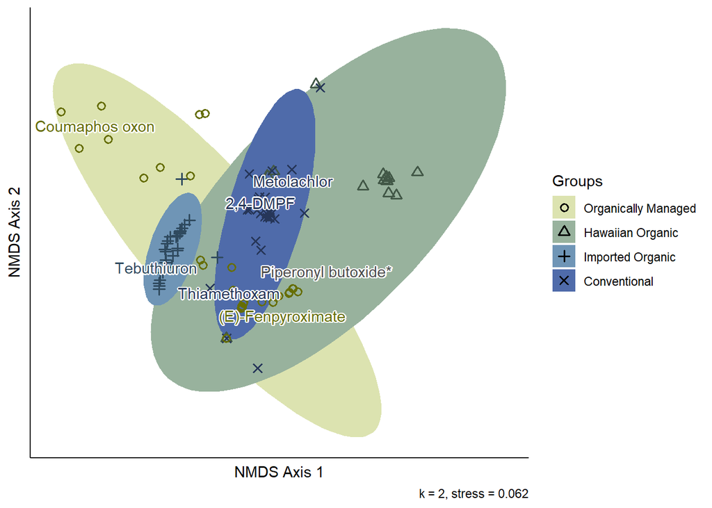

```r
meta.Ord <- meta.Honey %>%
  select(Sample.ID, Group) %>%
  mutate(Group = factor(Group, ordered = T, levels = styles.groupOrd)) %>%
  rename(Groups = Group)

# Data for NMDS --------------------------------------------------------------------
# See @link https://stackoverflow.com/a/65609236/5025767
df.fig4.NMDS <- data.H.Wide %>%
  column_to_rownames('Sample.ID') %>%
  select(-c(Colony.ID:Trt)) %>%
  filter(!if_all(everything(.), ~ . == 0)) %>% # Remove samples w/ no detections.
  select(-one_of(df.none %>% pull())) # Removes compounds w/ no detections

# Indicator Species Analysis -------------------------------------------------------
# See @link https://uw.pressbooks.pub/appliedmultivariatestatistics/chapter/isa/

# =(1)= Create clustering vector.
# Length of cluster vector MUST equal number of rows in df.fig4.NMDS
fct.ISA.grp <- meta.Ord %>%
  inner_join(
    df.fig4.NMDS %>% rownames_to_column("Sample.ID"),
    by = join_by(Sample.ID)
  ) %>%
  pull(Groups, Sample.ID)

# =(2)= Run the ISA.
set.seed(42) # Reproducibility
stat.ISA <- multipatt(x = df.fig4.NMDS, cluster = fct.ISA.grp)

# =(3)= Extract indicator species/compounds from the ISA
stat.ISA.tab <- stat.ISA$sign %>%
  select(-index) %>%

  # If compound is an indicator, replace value in table with group it indicates
  mutate(across(
    starts_with("s."),
    ~ ifelse(
      . == 1,
      gsub(
        "s.",
        "",
        cur_column()
      ),
      NA
    )
  )) %>%

  # Combine indicator groups into a single string, matching format from summary()
  unite(Groups, starts_with("s."), sep = "+", na.rm = T) %>%
  rownames_to_column("Cmpd") %>%

  # Only use significant compounds going forward
  filter(p.value <= 0.05) %>%

  # Lookup A & B values from ISA output
  rowwise() %>%
  mutate(
    A = as.data.frame(stat.ISA$A)[Cmpd, Groups],
    B = as.data.frame(stat.ISA$B)[Cmpd, Groups]
  ) %>%
  ungroup() %>%
  relocate(c(A, B), .before = stat) %>%

  # Format for display
  arrange(desc(stat)) %>%
  group_by(Groups)

# Run NMDS --------------------------------------------------------------------------
MDS.path <- "cache/nmds-result.rds"

if (!file.exists(MDS.path)) {
  # If the NMDS result does NOT exist, make it!
  set.seed(42) # Ensures reproducibility
  stat.MDS <- metaMDS(
    comm = df.fig4.NMDS,
    autotransform = F,
    distance = "bray",
    engine = "monoMDS",
    k = 2,
    model = "global",
    maxit = 999,
    trymax = 500,
    wascores = T,
    expand = T,
    noshare = F
  )
  saveRDS(stat.MDS, file = MDS.path)
} else {
  # The file exists, read data from it.
  stat.MDS <- readRDS(file = MDS.path)
}

stat.ISA.indic <- stat.ISA.tab %>% # Group col must be a factor to plot correctly
  mutate(Groups = factor(Groups, levels = levels(fct.ISA.grp))) %>%
  select(Cmpd, Groups)

source("functions/plot_NMDS.R")

(fig.4 <- plot_NMDS(
  MDS = stat.MDS,
  grp = fct.ISA.grp,
  indic = stat.ISA.indic,
  labs = styles.group,
  colors = lighten(styles.colors, 0.2)
)[[1]])
```

```r
ggsave(
  "Figure_4.tiff",
  plot = fig.4,
  path = "figures",
  dpi = 500,
  width = 7,
  height = 5
)
```

#### Table S4.Pairwise PERMANOVA comparing dissimilarity in composition of pesticides between groups of honey samples.

```r
fct.PERMANOVA <- fct.ISA.grp %>%
  fct_recode(
    "Organically Managed" = "OREI",
    "Hawaiian Organic" = "OG-HI",
    "Imported Organic" = "OG-IMP",
    "Conventional" = "CNV"
  )

adonis2(df.fig4.NMDS ~ fct.PERMANOVA, method = "bray")
```

```
## Permutation test for adonis under reduced model
## Permutation: free
## Number of permutations: 999
##
## adonis2(formula = df.fig4.NMDS ~ fct.PERMANOVA, method = "bray")
##           Df SumOfSqs      R2      F Pr(>F)
## Model      3   19.349 0.39111 24.837  0.001 ***
## Residual 116   30.123 0.60889
## Total    119   49.472 1.00000
## ---
## Signif. codes:  0 '***' 0.001 '**' 0.01 '*' 0.05 '.' 0.1 ' ' 1
```

```r
# Now do a pairwise PERMANOVA to see which groups differ
pairwise.adonis(df.fig4.NMDS, factors = fct.PERMANOVA) %>%
  select(-Df, -p.value, -sig) %>%
  gt() %>%
  fmt_number(decimals = 3) %>%
  cols_label(
    pairs = "Pairs",
    SumsOfSqs = "SS",
    F.Model = "F model",
    R2 = html("R<sup>2</sup>"),
    p.adjusted = "P adjusted"
  ) %>%
  tab_options(table.align = "left")
```

| Pairs | SS | F model | R<sup>2</sup> | P adjusted |
| --- | --- | --- | --- | --- |
| Hawaiian Organic vs Imported Organic | 6.405 | 32.508 | 0.414 | 0.006 |
| Hawaiian Organic vs Conventional | 3.530 | 13.437 | 0.230 | 0.006 |
| Hawaiian Organic vs Organically Managed | 3.592 | 10.221 | 0.148 | 0.006 |
| Imported Organic vs Conventional | 9.789 | 59.416 | 0.510 | 0.006 |
| Imported Organic vs Organically Managed | 8.550 | 33.170 | 0.318 | 0.006 |
| Conventional vs Organically Managed | 5.941 | 19.746 | 0.220 | 0.006 |

#### Table S5. Result of indicator species analysis (ISA) describing the degree of association between groups of honey samples.

```r
# Returns list of indicator species in each group in a readable format
# stat.ISA.summary <- summary(stat.ISA, indvalcomp = T)
stat.ISA.tab %>%
  mutate(
    Groups = case_match(
      Groups,
      "OREI" ~ "Organically Managed",
      "OG-HI" ~ "Hawaiian Organic",
      "OG-IMP" ~ "Imported Organic",
      "CNV" ~ "Conventional",
      "OREI+CNV" ~ "Organically Managed & Conventional",
    )
  ) %>%
  gt() %>%
  fmt_number(decimals = 3) %>%
  cols_label(Cmpd = "Compound", stat = "IV", p.value = "p") %>%
  tab_options(table.align = "left")
```

| Compound | A | B | IV | p |
| --- | --- | --- | --- | --- |
| Imported Organic |  |  |  |  |
| Tebuthiuron | 0.982 | 1.000 | 0.991 | 0.005 |
| Conventional |  |  |  |  |
| 2,4-DMPF | 0.878 | 0.862 | 0.870 | 0.005 |
| Metolachlor | 0.791 | 0.345 | 0.522 | 0.005 |
| Thiamethoxam | 1.000 | 0.103 | 0.322 | 0.015 |
| Organically Managed & Conventional |  |  |  |  |
| Piperonyl butoxide | 0.979 | 0.764 | 0.865 | 0.005 |
| Hawaiian Organic |  |  |  |  |
| 2,4-DMA | 0.949 | 0.556 | 0.726 | 0.005 |
| Organically Managed |  |  |  |  |
| Coumaphos oxon | 1.000 | 0.233 | 0.482 | 0.005 |
| (E)-Fenpyroximate | 1.000 | 0.140 | 0.374 | 0.005 |

### 3.2. Pesticide contamination relative to USDA organic tolerances

#### Stats for figure 5: Difference in likelihood of samples exceeding MRLs

```r
# Prepare data ----------------------------------------------------------------
df.fig5A.MRL <- df.fig2.heat %>%
  group_by(Sample.ID, Group) %>%
  summarize(
    # The binomial model expects Yes and No data as 1 or 0
    SampleExceed.model = ifelse(any(Exceed.Tol == "Yes"), 1, 0),
    # But for plotting, we want Yes and No labels
    SampleExceed.plot = ifelse(any(Exceed.Tol == "Yes"), "Yes", "No"),
    .groups = "drop"
  )

df.fig5B.MRLHeat <- df.fig2.heat %>%
  group_by(Cmpd) %>%
  filter(any(Exceed.Tol == "Yes")) %>%
  mutate(Cmpd = case_match(Cmpd, "Piperonyl butoxide" ~ "PBO", .default = Cmpd))

# Build models --------------------------------------------------------------
df.modFig5A.prior <- data.frame(
  prior = "normal(0, 2.5)",
  class = "fixef"
)

m.fig5A <- glmmTMB(
  SampleExceed.model ~ Group,
  data   = df.fig5A.MRL,
  family = "binomial",
  priors = df.modFig5A.prior
  )

m.fig5ANULL <- glmmTMB(
  SampleExceed.model ~ 1,
  data   = df.fig5A.MRL,
  family = "binomial",
  priors = df.modFig5A.prior
  )

anova(m.fig5A, m.fig5ANULL)
```

```
## Data: df.fig5A.MRL
## Models:
## m.fig5ANULL: SampleExceed.model ~ 1, zi=~0, disp=~1
## m.fig5A: SampleExceed.model ~ Group, zi=~0, disp=~1
##             Df    AIC    BIC  logLik deviance  Chisq Chi Df Pr(>Chisq)
## m.fig5ANULL  1 111.04 114.02 -54.520  109.040
## m.fig5A      4 102.88 114.81 -47.438   94.877 14.163      3   0.002691 **
## ---
## Signif. codes:  0 '***' 0.001 '**' 0.01 '*' 0.05 '.' 0.1 ' ' 1
```

```r
emmeans(m.fig5A, pairwise ~ Group, type = "response")
```

```
## $emmeans
##  Group    prob     SE  df asymp.LCL asymp.UCL
##  OREI   0.0214 0.0185 Inf  0.003878     0.109
##  OG-HI  0.2910 0.0822 Inf  0.158270     0.473
##  OG-IMP 0.0105 0.0158 Inf  0.000533     0.174
##  CNV    0.2585 0.0792 Inf  0.134368     0.439
##
## Confidence level used: 0.95
## Intervals are back-transformed from the logit scale
##
## $contrasts
##  contrast           odds.ratio      SE  df null z.ratio p.value
##  OREI / (OG-HI)         0.0533  0.0512 Inf    1  -3.051  0.0122
##  OREI / (OG-IMP)        2.0627  3.5500 Inf    1   0.421  0.9749
##  OREI / CNV             0.0628  0.0607 Inf    1  -2.864  0.0218
##  (OG-HI) / (OG-IMP)    38.6925 60.6000 Inf    1   2.333  0.0906
##  (OG-HI) / CNV          1.1771  0.6730 Inf    1   0.285  0.9919
##  (OG-IMP) / CNV         0.0304  0.0478 Inf    1  -2.225  0.1165
##
## P value adjustment: tukey method for comparing a family of 4 estimates
## Tests are performed on the log odds ratio scale
```

#### Figure 5. Samples exceeding surveillance MRLs for organic honey.

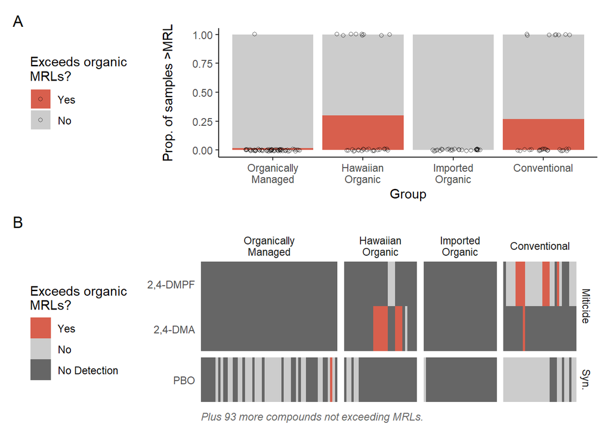

```r
# Fig 5A: Plot w/ proportion of samples above MRL ---------------------------------
fig.5A <- ggplot(
  data = df.fig5A.MRL,
  aes(x = Group, fill = SampleExceed.plot)
) +
  geom_bar(position = "fill") +
  geom_jitter(
    aes(y = ifelse(SampleExceed.plot == "Yes", 1, 0)),
    position = position_jitter(height = 0.01, width = 0.3),
    shape = 1,
    alpha = 0.6,
    color = "black"
  ) +
  # Wrap the Group labels at 13 characters
  scale_x_discrete(labels = str_wrap(styles.group, width = 13)) +
  scale_fill_manual(
    name = "Exceeds organic\nMRLs?",
    values = colors.tols,
    breaks = c("Yes", "No")
  ) +
  ylab("\nProp. of samples >MRL\n") +
  theme_classic() +
  theme(legend.position = "left")

# Fig 5A: Heatmap showing samples above tolerance --------------------------------
fig.5B <- ggplot(df.fig5B.MRLHeat) +
  geom_tile(aes(x = Sample.ID, y = Cmpd, fill = Exceed.Tol), alpha = 1) +
  facet_grid(
    Class.Pest ~ Group,
    scales = "free",
    space = "free",
    labeller = labeller(
      # Wrap the Group facet labels at 13 characters
      Group = setNames(str_wrap(styles.group, width = 13), names(styles.group))
    )
  ) +
  scale_fill_manual(name = "Exceeds organic\nMRLs?", values = colors.tols) +
  styles.heat +
  theme(legend.position = "left", plot.caption.position = "panel") +
  labs(caption = "Plus 93 more compounds not exceeding MRLs.")

# Assemble combined figure
((fig.5A) /
  free(fig.5B) +
  plot_layout(heights = c(2, 3)) +
  plot_annotation(tag_levels = 'A'))
```

```r
ggsave(
  "Figure_5.tiff",
  plot = last_plot(),
  path = "figures",
  dpi = 500,
  width = 7,
  height = 5
)
```

#### Figure 5B for visual abstract

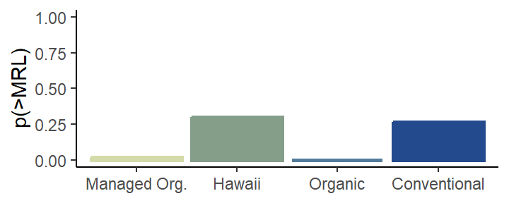

```r
(fig.5A.abs <- df.fig5A.MRL %>%
  mutate(SampleExceed.plot = case_match(SampleExceed.plot, "Yes" ~ 1, "No" ~ 0)) %>%
  group_by(Group) %>%
  summarize(ProbOverMRL = mean(SampleExceed.plot)) %>%

  ggplot(aes(x = Group, y = ProbOverMRL, color = Group, fill = Group)) +
  geom_bar(stat = "identity", linewidth = 1) +
  scale_x_discrete(
    labels = c(
      "OREI" = "Managed Org.",
      "OG-HI" = "Hawaii",
      "OG-IMP" = "Organic",
      "CNV" = "Conventional"
    )
  ) +
  scale_fill_manual(values = styles.colors) +
  scale_color_manual(values = styles.colors) +
  scale_y_continuous(limits = c(0, 1)) +
  ylab("p(>MRL)") +
  theme_classic() +
  theme(legend.position = "none", axis.title.x = element_blank()))
```

```r
ggsave(
  "Abstract_Fig5B.tiff",
  plot = fig.5A.abs,
  path = "figures",
  dpi = 500,
  width = 3.75,
  height = 1.5
)
```

### 3.3. Did landscape composition predict whether detected pesticide exposure?

Here, we use the [`CropScapeR`](https://github.com/cbw1243/CropScapeR) package to download the data directly from R. We create a function, called `get_apiary_CDL()` that makes this process a little easier. Given a dataframe of apiary coordinates (columns `Apiary`, `Lon`, `Lat`), it will return a dataframe of percentages of each crop/landscape type within each buffer. For optimization, the function also accepts inputs of `gc_shp` (T/F, outputs a shapefile of the buffer), `gc_tiff` (whether to save TIFFs of the buffered CDL), `gc_CDL` (T/F, useful if we want to save shapefiles but not actually download data yet), and `gc_log`, (T/F, whether the function should log progress to the console).

#### Table S6. Landscape composition within a 3 km radius of each of the 6 apiaries in 2024.

```r
# = (1) Download CDL data ===========================================================
path.CDL <- "cache/cdl-cropscape-out.csv"

# If the downloaded CDL data does NOT exist, create it! If it DOES exist, load it!
if (!file.exists(path.CDL)) {
  source("functions/get_apiary_CDL.R")

  CDL.OREI.1km <- get_apiary_CDL(
    meta.farms,
    gc_rad = 1,
    gc_yr = 2024,
    gc_dTol = 40
  )
  CDL.OREI.3km <- get_apiary_CDL(
    meta.farms,
    gc_rad = 3,
    gc_yr = 2024,
    gc_dTol = 75
  )
  CDL.OREI.6km <- get_apiary_CDL(
    meta.farms,
    gc_rad = 6.4,
    gc_yr = 2024,
    gc_dTol = 140
  )

  data.CDL <- bind_rows(CDL.OREI.1km, CDL.OREI.3km, CDL.OREI.6km)

  rm(CDL.OREI.1km, CDL.OREI.3km, CDL.OREI.6km)

  write_csv(data.CDL, path.CDL)

} else {

  data.CDL <- read_csv(path.CDL, col_types = "ffffd")

}

rm(path.CDL, get_apiary_CDL)
# = (2) Classify habitat ============================================================

# Generate a list to classify manually
# data.CDL %>% select(Crop) %>% unique() %>%
#   write_csv("cdl-crops.csv")

# Read the classified crops
meta.cropHab <- read_csv(
  "data/metadata/cdl-crops-classified.csv",
  col_types = "ff"
)

# = (3) Create a dataframe combining contamination + landscape data =================
df.landscape <- left_join(
  # Join just the New York and Pennsylvania honey data
  data.H.Long %>%
    filter(Group == "OREI") %>%
    group_by(Apiary, Trt, Colony.ID) %>%
    summarise(
      ppb.sum = sum(ppb),
      num.Cmpd = length(ppb[ppb > 0]),
      .groups = "drop"
    ),

  # with the classified habitat dataframe
  data.CDL %>%
    left_join(meta.cropHab, by = "Crop") %>%
    group_by(Apiary, Year, Rad.km, Habitat) %>%
    summarize(Pct.Habitat = sum(Pct), .groups = "drop"),

  by = join_by(Apiary),
  relationship = "many-to-many"
) %>%

  # Wider format
  pivot_wider(
    names_from = Habitat,
    values_from = Pct.Habitat,
    names_prefix = "Pct.",
    values_fill = 0
  ) %>%

  pivot_wider(
    names_from = Rad.km,
    values_from = starts_with("Pct."),
    names_glue = "{.value}_{Rad.km}km"
  )

# = (4) Summary table ==============================================================
df.landscape %>%
  select(Apiary, ends_with("_3km")) %>%
  unique() %>%
  arrange(as.character(Apiary)) %>%
  gt() %>%
  fmt_number(decimals = 2) %>%
  tab_spanner(label = "Percent Habitat", columns = 2:5) %>%
  # fmt: skip
  cols_label(
    Apiary  = "Apiary",
    Pct.Ag_3km   = "Agricultural",
    Pct.Semi_3km = "Seminatural",
    Pct.Dev_3km  = "Developed",
    Pct.Nat_3km  = "Natural"
  ) %>%
  tab_options(table.align = "left")
```

| Apiary | Percent Habitat Agricultural | Percent Habitat Seminatural | Percent Habitat Developed | Percent Habitat Natural |
| --- | --- | --- | --- | --- |
| NY-1 | 4.62 | 37.07 | 5.00 | 53.31 |
| NY-2 | 3.79 | 32.46 | 4.63 | 59.12 |
| NY-3 | 2.05 | 18.43 | 4.95 | 74.57 |
| PA-1 | 21.89 | 22.41 | 6.42 | 49.28 |
| PA-2 | 4.15 | 14.33 | 5.14 | 76.38 |
| PA-3 | 21.23 | 20.85 | 23.03 | 34.88 |

#### Table S7. Summary of GLMMs used to examine the relationship between landscape composition and pesticide contamination in New York and Pennsylvania honey

```r
# fmt: skip
m.land.sum     <- glmmTMB(ppb.sum ~ Pct.Ag_1km + Pct.Ag_3km + Pct.Ag_6.4km +
                          Pct.Semi_1km + Pct.Semi_3km + Pct.Semi_6.4km + Pct.Dev_1km +
                          Pct.Dev_3km + Pct.Dev_6.4km + (1|Apiary),
                          data   = df.landscape,
                          family = "tweedie",
                          na.action = "na.fail")
# fmt: skip
m.land.sumNULL <- glmmTMB(ppb.sum ~ (1|Apiary),
                          data   = df.landscape,
                          family = "tweedie",
                          na.action = "na.fail")
# fmt: skip
m.land.num     <- glmmTMB(num.Cmpd ~ Pct.Ag_1km + Pct.Ag_3km + Pct.Ag_6.4km +
                          Pct.Semi_1km + Pct.Semi_3km + Pct.Semi_6.4km + Pct.Dev_1km +
                          Pct.Dev_3km + Pct.Dev_6.4km + (1|Apiary),
                          data   = df.landscape,
                          family = "poisson",
                          na.action = "na.fail")
# fmt: skip
m.land.numNULL <- glmmTMB(num.Cmpd ~ (1|Apiary),
                          data   = df.landscape,
                          family = "poisson",
                          na.action = "na.fail")

m.test <- glmmTMB(num.Cmpd ~ Pct.Ag_1km + (1|Apiary),
                          data   = df.landscape,
                          family = "poisson",
                          na.action = "na.fail")

# Function implements dredge() with custom outputs:
# R^2 and results from a likelihood ratio test
# It also saves results in a table for publication
do_dredge <- function(model, nModel) {
  out <- dredge(
    model,
    m.lim = c(0, 1),
    extra = list(
      # fmt: skip
      "Rsq" = function(x) r.squaredLR(x, nModel),
      "LRtest" = function(x) {
        anova <- anova(x, nModel)
        c(
          "Chisq" = anova$Chisq[2],
          "df" = anova$`Chi Df`[2],
          "p" = anova$`Pr(>Chisq)`[2]
        )
      },
      "model.int" = function(x) fixef(x)$cond[1] %>% unname(),
      "model.slope" = function(x) fixef(x)$cond[2] %>% unname()
    )
  )

  tab <- out %>%
    # I'll convert the wide output from dredge() and list the predictor(s) in a column
    # First, column names need to be clean
    rename_with(~ make.names(.) %>% str_remove("\\.$")) %>%
    select(-cond..Int., -disp..Int.) %>%
    # If we have a numeric value for the predictor, replace value with the predictor
    mutate(across(
      starts_with("cond."),
      ~ ifelse(
        !is.na(.),
        gsub("cond.", "", cur_column()),
        NA
      )
    )) %>%
    # Combine predictor names into single column
    unite(Predictor, starts_with("cond."), sep = " + ", na.rm = T) %>%
    # Remove null model and row names
    mutate(Predictor = ifelse(Predictor == "", "Null model", Predictor)) %>%
    remove_rownames()

  return(list(table = tab, models = out))
}

# Run dredge and save output
stat.dredge.S <- do_dredge(m.land.sum, m.land.sumNULL)
stat.dredge.N <- do_dredge(m.land.num, m.land.numNULL)

# Save summary table output from drege
df.land.dredge <- bind_rows(
  stat.dredge.S$table %>%
    mutate(Response = "Sum", .before = Predictor),

  stat.dredge.N$table %>%
    mutate(Response = "Num", .before = Predictor)
)

df.land.dredge %>%
  select(Response, Predictor, model.slope, Rsq, starts_with("LRtest"), AICc, delta) %>%

  # Format data within table
  separate_wider_delim(
    Predictor,
    delim = "_",
    names = c("Habitat", "Radius"),
    too_few = "align_start"
  ) %>%

  mutate(
    Response = case_match(
      Response,
      "Sum" ~ "Additive amount of residues",
      "Num" ~ "Number of compounds per sample"
    ),
    Habitat = case_match(
      Habitat,
      "Pct.Semi" ~ "Seminatural",
      "Pct.Dev" ~ "Developed",
      "Pct.Ag" ~ "Agricultural",
      .default = Habitat
    ),
    model.rel = case_match(
      as.character(sign(model.slope)),
      "1" ~ "Positive",
      "-1" ~ "Negative"
    )
  ) %>%
  select(-model.slope) %>%
  relocate(model.rel, .after = Radius) %>%
  gt(groupname_col = "Response") %>%
  tab_options(row_group.as_column = T, table.align = "left") %>%
  cols_width(Response ~ "160px") %>%
  tab_stubhead("Response") %>%
  tab_spanner(label = "Predictor", columns = 2:3) %>%
  cols_label(
    model.rel = "Relationship",
    Rsq = html("R<sup>2</sup><sub>LR</sub>"),
    LRtest.Chisq = html("&Chi;<sup>2</sup>"),
    LRtest.df = "df",
    LRtest.p = "p",
    delta = html("&Delta;AICc")
  ) %>%
  fmt_number(columns = c(5:6, 8:10), decimals = 3) %>%
  tab_style(
    style = list(cell_text(weight = "bold")),
    locations = cells_body(columns = LRtest.p, rows = LRtest.p <= 0.05)
  )
```

[output not shown]

#### Figure S2. Visualizing results from landscape model building

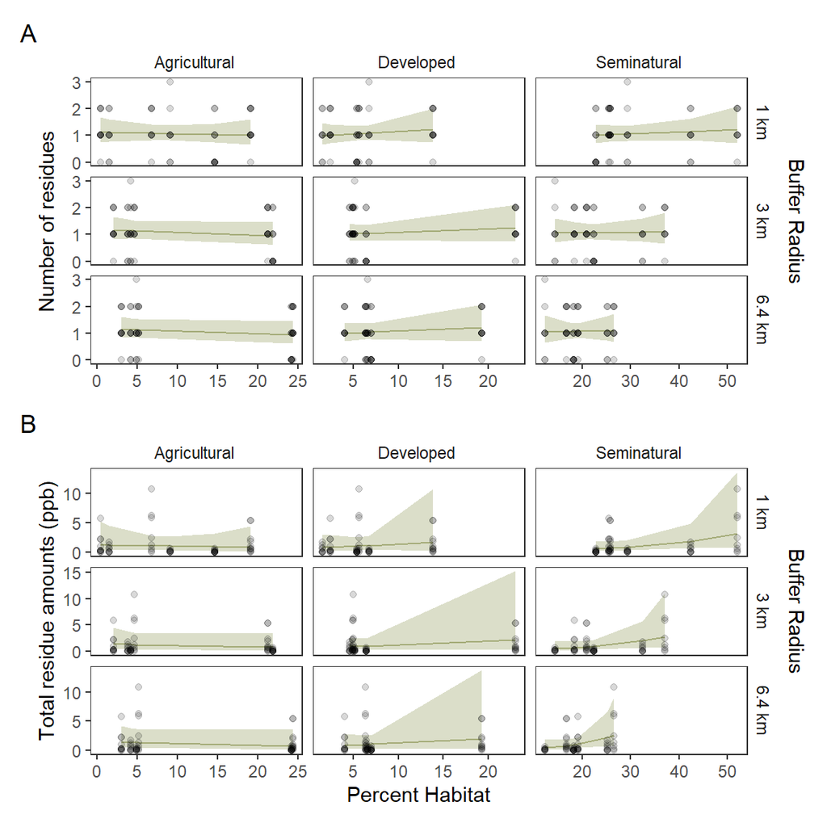

```r
# Wrangle wide data for the facetted plot.
# Use Habitat and buffer radius as columns
# To plot regression line from glmm (I saved the slope and intercept in
# df.land.dredge), make a dataframe of these values
# -----------------------------------------------------------------------------------
df.figS2 <- df.landscape %>%
  select(-starts_with("Pct.Nat")) %>%
  pivot_longer(
    !c(Apiary:Year),
    names_to = c("Habitat", "Rad.km"),
    names_pattern = "Pct.(.*)_(.*)km",
    values_to = "Pct"
  ) %>%
  mutate(
    Habitat = case_match(
      Habitat,
      "Ag" ~ "Agricultural",
      "Semi" ~ "Seminatural",
      "Dev" ~ "Developed"
    )
  )

# For plot formatting ----------------------------------------------------------
facet_lab <- function(s) {
  # fmt: skip
  paste(s, ifelse(suppressWarnings(is.na(as.numeric(s))), "", "km")
  )
}

styles.landColor <- darken(styles.colors[1], amount = 0.2)

# Function to plot each panel of the landscape visualization
plot_landscape <- function(
  models = df.land.dredge,
  dredge = stat.dredge.N,
  points = df.figS2,
  resp_subset = "",
  y_var = "num.Cmpd"
) {
  path.LandPred <- paste0("cache/LandscapePred", resp_subset, ".csv")

  if (!file.exists(path.LandPred)) {
    predictions <- data.frame()

    # Loop thru each model we considered
    for (n in 2:nrow(filter(models, Response == resp_subset))) {
      # Retrieve predictor we should generate predictions for
      term <- filter(models, Response == resp_subset)$Predictor[n]

      # Retrieves model from dredge output. Second row of stat.dredge.N
      get.models(dredge$models, subset = n)[[1]]

      # generates prediction df
      predict <- ggpredict(
        get.models(dredge$models, subset = n)[[1]],
        terms = term,
        bias_correction = T
      ) %>%
        as.data.frame() %>%
        select(x, predicted, conf.low, conf.high) %>%
        mutate(Predictor = term)

      # Add new set of predictions to our dataframe
      predictions <- bind_rows(predictions, predict)

      # Track progress
      message(paste("Predicted model", n))
    }

    # Format the dataframe for plotting
    predictions <- predictions %>%
      separate_wider_regex(
        cols = Predictor,
        c("Pct.", Habitat = ".*", "_", Rad.km = ".*", "km")
      ) %>%
      mutate(
        Habitat = case_match(
          Habitat,
          "Ag" ~ "Agricultural",
          "Semi" ~ "Seminatural",
          "Dev" ~ "Developed"
        )
      )

    # Cache predictions
    write_csv(predictions, path.LandPred)
  } else {
    predictions <- read_csv(path.LandPred, show_col_types = F)
  }

  # Construct the plot
  plot <- ggplot(points) +
    facet_grid(
      Rad.km ~ Habitat,
      scales = "free",
      labeller = as_labeller(facet_lab)
    ) +
    geom_ribbon(
      data = predictions,
      aes(x = x, ymin = conf.low, ymax = conf.high),
      alpha = 0.4,
      fill = styles.landColor,
    ) +
    geom_line(
      data = predictions,
      aes(x = x, y = predicted),
      color = styles.landColor
    ) +
    geom_point(aes(x = Pct, y = .data[[y_var]]), alpha = 0.15) +
    theme_bw() +
    theme(
      strip.background = element_rect(fil = NA, color = NA),
      panel.grid.major = element_blank(),
      panel.grid.minor = element_blank()
    ) +
    xlab("Percent Habitat") +
    # The "secondary axis" label labels the vertical facets
    scale_y_continuous(
      sec.axis = sec_axis(transform = ~., breaks = NULL, name = "Buffer Radius")
    )

  return(plot)
}
# Construct plots -----------------------------------------------------------------
fig.S2A <- plot_landscape(
  models = df.land.dredge,
  dredge = stat.dredge.N,
  points = df.figS2,
  resp_subset = "Num",
  y_var = "num.Cmpd"
) +
  ylab("Number of residues")

fig.S2B <- plot_landscape(
  models = df.land.dredge,
  dredge = stat.dredge.S,
  points = df.figS2,
  resp_subset = "Sum",
  y_var = "ppb.sum"
) +
  ylab("Total residue amounts (ppb)")

fig.S2A /
  fig.S2B +
  plot_annotation(tag_levels = 'A') +
  plot_layout(axis_titles = "collect_x")
```

```r
ggsave(
  "Supplemental_FigS2.tiff",
  plot = last_plot(),
  path = "figures",
  dpi = 500,
  width = 6,
  height = 6
)
```

[^1]: Cornell University, benedict.demoras@gmail.com
[^2]: Cornell University
[^3]: Cornell University
[^4]: The Pennsylvania State University
[^5]: The Pennsylvania State University
[^6]: Cornell University